# Final Project - Chronic Disease Burden in the U.S.

Hojoon Lee (hojoonle)

12-04-2025

## Loading packages

The code chunk below loads the packages used throughout the analysis.

```r
library(tidyverse)
```

## 1. Introduction

In this project, I use the U.S. Chronic Disease Indicators (CDI) dataset from the Centers for Disease Control and Prevention (CDC). The dataset contains many measures related to chronic disease burden, such as adult obesity, smoking, and heart disease mortality, for U.S. states over time.

My main research questions are:

1. Do adult obesity rates differ across U.S. regions (Northeast, Midwest, South, West)?
2. Is the South significantly different from the other regions?
3. Is there a relationship between adult smoking and heart disease mortality?
4. When modeled together, do both obesity and smoking help explain heart disease mortality?

These questions matter for public policy because chronic diseases are a major driver of health care costs, disability, and premature death. If certain regions or risk factors stand out, that can help public health officials decide where to focus prevention and intervention efforts. Before analyzing the data, I expected the South to show higher adult obesity rates than the other regions, and I also expected higher smoking and obesity to be associated with higher heart disease mortality.

I chose this dataset because I am interested in how chronic disease risks differ across U.S. regions and how these patterns relate to broader public health challenges such as obesity and cardiovascular disease.

### 1.1 Read the U.S. Chronic Disease Indicators dataset

```r
cdi <- read.csv("U.S._Chronic_Disease_Indicators.csv", stringsAsFactors = TRUE)
```

The CDI dataset used in this project was obtained from the [U.S. Chronic Disease Indicators portal](https://catalog.data.gov/dataset/u-s-chronic-disease-indicators) (accessed December 2, 2025).

### 1.2 Examine structure and summary

```r
str(cdi)
```

```
## 'data.frame':    309215 obs. of  34 variables:
##  $ YearStart                : int  2020 2015 2015 2015 2015 2015 2015 2015 2015 2015 ...
##  $ YearEnd                  : int  2020 2019 2019 2019 2019 2019 2019 2019 2019 2019 ...
##  $ LocationAbbr             : Factor w/ 55 levels "AK","AL","AR",..: 47 3 5 6 11 18 23 33 36 39 ...
##  $ LocationDesc             : Factor w/ 55 levels "Alabama","Alaska",..: 47 4 5 6 11 18 21 32 34 39 ...
##  $ DataSource               : Factor w/ 14 levels "ACS","AEDS","ANRF",..: 4 11 11 11 11 11 11 11 11 11 ...
##  $ Topic                    : Factor w/ 19 levels "Alcohol","Arthritis",..: 11 4 4 4 4 4 4 4 4 4 ...
##  $ Question                 : Factor w/ 109 levels "2 or more chronic conditions among adults",..: 95 65 16 65 89 65 65 65 14 14 ...
##  $ Response                 : logi  NA NA NA NA NA NA ...
##  $ DataValueUnit            : Factor w/ 8 levels "%","cases per 1,000",..: 6 6 6 6 6 6 6 6 6 6 ...
##  $ DataValueType            : Factor w/ 12 levels "Adjusted rate by age, sex, race and ethnicity",..: 2 10 10 10 10 10 10 10 10 10 ...
##  $ DataValue                : num  2.9 9537 486 2880 519 ...
##  $ DataValueAlt             : num  2.9 9537 486 2880 519 ...
##  $ DataValueFootnoteSymbol  : Factor w/ 10 levels "","*","****",..: 1 1 1 1 1 1 1 1 1 1 ...
##  $ DataValueFootnote        : Factor w/ 10 levels "","Data cannot be calculated",..: 1 1 1 1 1 1 1 1 1 1 ...
```

[output cut: 20 more lines]

```r
summary(cdi)
```

```
##    YearStart       YearEnd      LocationAbbr           LocationDesc                     DataSource
##  Min.   :2015   Min.   :2019   US     :  5763   United States:  5763   BRFSS                 :195594
##  1st Qu.:2019   1st Qu.:2019   TN     :  5750   Tennessee    :  5750   NVSS                  : 50232
##  Median :2020   Median :2020   AL     :  5748   Alabama      :  5748   YRBSS                 : 17710
##  Mean   :2020   Mean   :2020   AR     :  5748   Arkansas     :  5748   US Cancer DVT         : 17520
##  3rd Qu.:2021   3rd Qu.:2021   CO     :  5748   Colorado     :  5748   CMS Part A Claims Data: 11232
##  Max.   :2022   Max.   :2022   CT     :  5748   Connecticut  :  5748   PRAMS                 :  7182
##                                (Other):274710   (Other)      :274710   (Other)               :  9745
##                                              Topic                                                                                 Question
##  Cardiovascular Disease                         : 30709   Binge drinking frequency among adults who binge drink                        :  5720
##  Chronic Obstructive Pulmonary Disease          : 26951   Binge drinking intensity among adults who binge drink                        :  5680
##  Nutrition, Physical Activity, and Weight Status: 26069   Asthma mortality among all people, underlying cause                          :  5616
##  Health Status                                  : 25612   Cerebrovascular disease (stroke) mortality among all people, underlying cause:  5616
##  Alcohol                                        : 25321   Chronic liver disease mortality among all people, underlying cause           :  5616
##  Cancer                                         : 22358   Coronary heart disease mortality among all people, underlying cause          :  5616
##  (Other)                                        :152195   (Other)                                                                      :275351
##  Response                 DataValueUnit                    DataValueType      DataValue          DataValueAlt       DataValueFootnoteSymbol
##  Mode:logical   %                :203382   Crude Prevalence       :128198   Min.   :      0.0   Min.   :      0.0          :207499
##  NA's:309215    Number           : 54104   Age-adjusted Prevalence: 75019   1st Qu.:     12.4   1st Qu.:     12.4   ****   : 52652
##                 cases per 100,000: 31980   Number                 : 27888   Median :     27.0   Median :     27.0   ~      : 28763
##                 per 100,000      : 11680   Crude Rate             : 27524   Mean   :    694.4   Mean   :    735.7   *      : 12833
##                 cases per 1,000  :  7488   Age-adjusted Rate      : 23624   3rd Qu.:     57.8   3rd Qu.:     57.8   #      :  5738
##                 Years            :   312   Crude Mean             :  8580   Max.   :2925456.0   Max.   :2925456.0   ###    :   937
##                 (Other)          :   269   (Other)                : 18382   NA's   :100019      NA's   :100019      (Other):   793
##                                                                                                             DataValueFootnote  LowConfidenceLimit
##                                                                                                                      :207499   Min.   :   0.00
##  Data suppressed; denominator < 50 or relative standard error > 30%                                                  : 52652   1st Qu.:   9.10
##  Data suppressed; too few respondents or cases                                                                       : 28763   Median :  19.50
##  No data available                                                                                                   : 12833   Mean   :  36.83
##  No data available for this indicator because the module was not used by the state or territory                      :  5738   3rd Qu.:  40.30
##  Interpret with caution: 95% confidence interval width is greater than 20 percentage points or 1.2 times the estimate:   937   Max.   :1427.00
##  (Other)                                                                                                             :   793   NA's   :120330
##  HighConfidenceLimit   StratificationCategory1                                       Stratification1   StratificationCategory2 Stratification2
##  Min.   :   0.00     Age           : 32472     Overall                                       : 29201   Mode:logical            Mode:logical
##  1st Qu.:  14.00     Grade         :  5060     Black, non-Hispanic                           : 28000   NA's:309215             NA's:309215
##  Median :  29.20     Overall       : 29201     Hispanic                                      : 28000
##  Mean   :  46.03     Race/Ethnicity:188664     White, non-Hispanic                           : 28000
##  3rd Qu.:  54.30     Sex           : 53818     American Indian or Alaska Native, non-Hispanic: 27980
##  Max.   :1485.90                               Female                                        : 26909
##  NA's   :120325                                (Other)                                       :141125
```

[output cut: 9 more lines]

```
##  Mode:logical   CRDPREV   :128198   AGE    : 32472            OVR    : 29201    Mode:logical              Mode:logical      Mode:logical
##  NA's:309215    AGEADJPREV: 75019   GRADE  :  5060            BLK    : 28000    NA's:309215               NA's:309215       NA's:309215
##                 NMBR      : 27888   OVERALL: 29201            HIS    : 28000
##                 CRDRATE   : 27524   RACE   :188664            WHT    : 28000
##                 AGEADJRATE: 23624   SEX    : 53818            AIAN   : 27980
##                 CRDMEAN   :  8580                             SEXF   : 26909
##                 (Other)   : 18382                             (Other):141125
##  StratificationID3
##  Mode:logical
##  NA's:309215
##
##
##
##
##
```

The dataset consists of 309,215 observations on 34 variables.

- It includes 3 integer variables (YearStart, YearEnd, LocationID) that record the year range and numeric location identifier.
- There are several numeric variables such as DataValue, DataValueAlt, LowConfidenceLimit, and HighConfidenceLimit that provide indicator values and basic statistics.
- The remaining variables are factors describing geography (LocationAbbr, LocationDesc), topic and question text (Topic, Question), data source (DataSource), units and types (DataValueUnit, DataValueType), and stratification categories like sex, age, race/ethnicity and so on.

Together, these variables describe chronic disease indicators for different U.S. states, years, and population subgroups.

To simplify the analysis and avoid problems with missing outcome values, I keep only rows with non-missing `DataValue`.

The dataset covers indicators reported by states from approximately 2015 to 2022, although the exact range varies by topic.

### 1.3 Simplify the dataset

```r
cdi_clean <- cdi %>%
filter(!is.na(DataValue))
nrow(cdi_clean)
```

```
## [1] 209196
```

At this stage, the cleaned dataset still includes national-level rows (LocationAbbr = “US”). Later, in Section 3, I restrict the data to state-only observations when assigning census regions.

## 2. Selecting Key Indicators

From the many possible indicators in the CDI system, I focus on three important measures that are widely recognized as key public health concerns:

- Adult obesity
- Adult current cigarette smoking
- Heart disease mortality

### 2.1 A sample of question text

```r
head(unique(cdi_clean$Question), 20)
```

```
##  [1] Recent activity limitation among adults
##  [2] Invasive cancer (all sites combined), incidence
##  [3] Cervical cancer mortality among all females, underlying cause
##  [4] Prostate cancer mortality among all males, underlying cause
##  [5] Breast cancer mortality among all females, underlying cause
##  [6] Invasive cancer (all sites combined) mortality among all people, underlying cause
##  [7] Diabetic ketoacidosis mortality among all people, underlying or contributing cause
##  [8] Lung and bronchial cancer mortality among all people, underlying cause
##  [9] Colon and rectum (colorectal) cancer mortality among all people, underlying cause
## [10] Short sleep duration among children aged 4 months to 14 years
## [11] Influenza vaccination among adults
## [12] Children and adolescents aged 6-13 years meeting aerobic physical activity guideline
## [13] Receipt of evidence-based preventive dental services in the past 12 months among children and adolescents aged 1-17 years
## [14] Arthritis among adults
## [15] Current asthma among adults
## [16] Taking medicine to control high blood pressure among adults with high blood pressure
## [17] Coronary heart disease mortality among all people, underlying cause
## [18] Adults with any disability
## [19] Frequent mental distress among adults
## [20] Short sleep duration among high school students
## 109 Levels: 2 or more chronic conditions among adults Activity limitation due to arthritis among adults with arthritis ... Work limitation due to arthritis among adults aged 18-64 years with arthritis
```

### 2.2 Adult obesity indicator

```r
obesity <- cdi_clean %>%
filter(Question == "Obesity among adults",
Topic == "Nutrition, Physical Activity, and Weight Status")

summary(obesity$DataValue)
```

```
##    Min. 1st Qu.  Median    Mean 3rd Qu.    Max.
##    8.20   29.80   33.80   33.69   37.90   71.10
```

The summary statistics for adult obesity, DataValue expressed in percent, indicate the following:

- Minimum (8.2%): The lowest reported adult obesity rate among all state-year combinations in the dataset is 8.2%.
- 1st Quartile (29.8%): One quarter of obesity observations fall below 29.8%.
- Median (33.8%): Half of all observations fall below 33.8%, meaning a “typical” state-year obesity rate is in the mid-30% range.
- Mean (33.69%): The average obesity rate is also about 33.7%, very close to the median, suggesting the distribution is fairly symmetric.
- 3rd Quartile (37.9%): Three quarters of the observations fall below 37.9%, meaning many states fall between 30–38%.
- Maximum (71.1%): The highest observed obesity rate is 71.1%, likely due to a small subgroup or stratified estimate producing an unusually large value.

Overall, obesity among adults typically falls between 30%–40% across states, with a few extreme outliers.

### 2.3 Adult current cigarette smoking indicator

```r
smoking <- cdi_clean %>%
filter(Question == "Current cigarette smoking among adults",
Topic == "Tobacco")

summary(smoking$DataValue)
```

```
##    Min. 1st Qu.  Median    Mean 3rd Qu.    Max.
##    0.00   12.30   15.60   16.72   19.50   53.90
```

For adult current cigarette smoking, the summary statistics indicate:

- Minimum (0.0%): Some state-year-subgroup observations report 0% smoking, often due to small cell sizes.
- 1st Quartile (12.3%): One quarter of observations fall below 12.3%.
- Median (15.6%): A typical state-year smoking rate is around 15.6%.
- Mean (16.72%): The average smoking rate is 16.7%, slightly higher than the median, suggesting a few higher values pull the mean upward.
- 3rd Quartile (19.5%): Three quarters of smoking rates fall below 19.5%.
- Maximum (53.9%): The highest observed smoking value is 53.9%, which is likely associated with specific demographic subgroups rather than entire state populations.

Overall, most adult smoking rates fall between 12%–20%, with a few much higher subgroup estimates.

### 2.4 Heart disease mortality indicator

```r
heart <- cdi_clean %>%
filter(Question == "Diseases of the heart mortality among all people, underlying cause",
Topic == "Cardiovascular Disease")

summary(heart$DataValue)
```

```
##     Min.  1st Qu.   Median     Mean  3rd Qu.     Max.
##      4.5    104.5    196.4   3712.0    762.4 696962.0
```

Heart disease mortality (DataValue) is reported as a rate, not a percentage. The summary shows:

- Minimum (4.5): The lowest reported heart disease mortality rate is 4.5 deaths per population unit (usually per 100,000).
- 1st Quartile (104.5): A quarter of observations fall below 104.5.
- Median (196.4): A typical state-year mortality rate is around 196 deaths per 100,000.
- Mean (3712.0): The mean is extremely high (3,712) due to a few very large outliers.
- 3rd Quartile (762.4): Three quarters of values fall below 762, showing that most observations are far below the extreme outliers.
- Maximum (696,962.0): The maximum is extraordinarily high and indicates a reporting anomaly or subgroup with extremely small denominator values.

This distribution is highly skewed, with extreme outliers driving the mean much higher than the median.

These subsets provide percentage values for obesity and smoking and mortality rates for heart disease, across states and years. They form the basis of the comparative and regression analyses that follow.

## 3. Adding U.S. Census Regions

To compare health indicators across broader geographic areas, I map each state to one of the four U.S. Census regions (Northeast, Midwest, South, West) and join this region information to the CDI dataset. I also exclude the national aggregate (LocationAbbr == “US”) to focus on state-level variation.

```r
state_region <- tibble(
LocationAbbr = c(
"ME","NH","VT","MA","RI","CT","NY","NJ","PA", # Northeast
"OH","IN","IL","MI","WI","MN","IA","MO","ND",
"SD","NE","KS", # Midwest
"DE","MD","DC","VA","WV","NC","SC","GA","FL",
"KY","TN","AL","MS","AR","LA","OK","TX", # South
"MT","ID","WY","CO","NM","AZ","UT","NV",
"WA","OR","CA","AK","HI" # West
),
Region = c(
rep("Northeast", 9),
rep("Midwest", 12),
rep("South", 17),
rep("West", 13)
)
)
```

### 3.1 Recreate cleaned dataset with state-only observations and region

```r
cdi_clean <- cdi %>%
filter(!is.na(DataValue),
LocationAbbr != "US") %>%
left_join(state_region, by = "LocationAbbr")
```

### 3.2 Recreate key indicator subsets from the updated cdi_clean

```r
obesity <- cdi_clean %>%
filter(Question == "Obesity among adults",
Topic == "Nutrition, Physical Activity, and Weight Status")

smoking <- cdi_clean %>%
filter(Question == "Current cigarette smoking among adults",
Topic == "Tobacco")

heart <- cdi_clean %>%
filter(Question == "Diseases of the heart mortality among all people, underlying cause",
Topic == "Cardiovascular Disease")

table(obesity$Region, useNA = "ifany")
```

```
##
##   Midwest Northeast     South      West      <NA>
##       913       625      1222       990       146
```

Now each observation in the indicator subsets includes both the state and its corresponding census region, which allows me to compare obesity rates across regions and test specific hypotheses about the South.

## 4. Exploratory Data Analysis (EDA)

In this section, I summarize the distribution of topics and key health indicators to better understand overall patterns before running formal statistical tests.

### 4.1 Topic counts

```r
topic_counts <- sort(table(cdi_clean$Topic), decreasing = TRUE)

topic_counts_df <- data.frame(
  Topic = names(topic_counts),
  Count = as.numeric(topic_counts)
)

knitr::kable(
  head(topic_counts_df, 10),
  caption = "Top 10 CDI topics by number of records"
)
```

Top 10 CDI topics by number of records

| Topic | Count |
| --- | --- |
| Cardiovascular Disease | 22861 |
| Nutrition, Physical Activity, and Weight Status | 19169 |
| Health Status | 18744 |
| Chronic Obstructive Pulmonary Disease | 17831 |
| Cancer | 16114 |
| Alcohol | 15957 |
| Immunization | 11983 |
| Social Determinants of Health | 11977 |
| Arthritis | 11745 |
| Mental Health | 11479 |

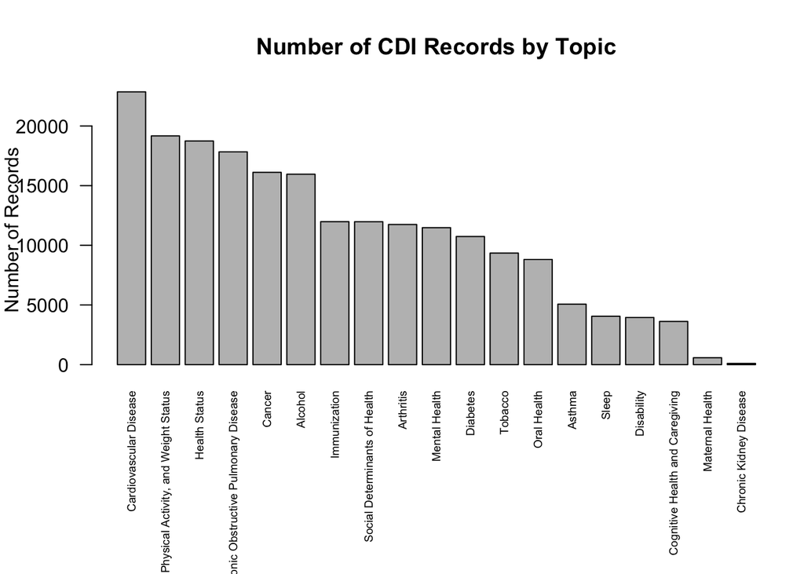

```r
op <- par(mar = c(9, 4, 4, 1))

barplot(topic_counts,
main = "Number of CDI Records by Topic",
ylab = "Number of Records",
las = 2,
cex.names = 0.6)
```

```r
par(op)
```

This bar chart shows that cardiovascular disease, nutrition/physical activity/weight status, health status, chronic obstructive pulmonary disease, and cancer are among the most frequently recorded topics in the CDI dataset.

### 4.2 Summary statistics for key indicators

```r
med.mean.and.sd <- function(x){
c(median = median(x, na.rm = TRUE),
mean = mean(x, na.rm = TRUE),
stddev = sd(x, na.rm = TRUE))
}

rbind(
Obesity = med.mean.and.sd(obesity$DataValue),
Smoking = med.mean.and.sd(smoking$DataValue),
HeartDeath = med.mean.and.sd(heart$DataValue)
) %>% round(3)
```

```
##            median     mean   stddev
## Obesity     33.90   33.685    7.521
## Smoking     15.60   16.755    7.054
## HeartDeath 195.95 1961.240 5574.864
```

This table shows the typical level and variability of each indicator. In this sample, median adult obesity is in the mid-30% range, adult smoking is in the mid-teens, and heart disease mortality has a very wide range. The wide spread for mortality likely reflects differences in population size, coding, and underlying risk profiles across states and years.

### 4.3 Distribution of obesity and heart disease

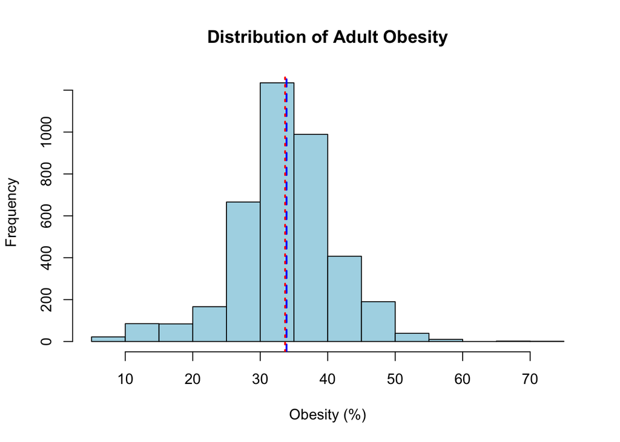

```r
hist(obesity$DataValue,
main = "Distribution of Adult Obesity",
xlab = "Obesity (%)",
col  = "lightblue",
breaks = 20)

abline(v = median(obesity$DataValue, na.rm = TRUE), col="blue", lwd=2, lty=2)
abline(v = mean(obesity$DataValue, na.rm = TRUE),   col="red",  lwd=2, lty=3)
```

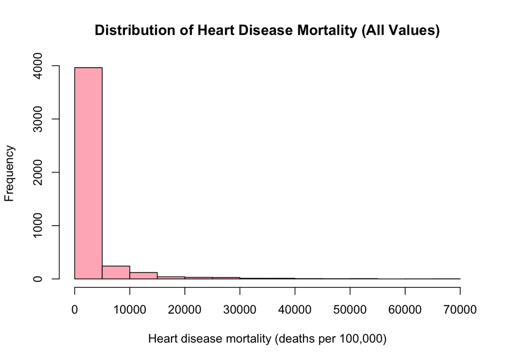

```r
# Full distribution
hist(heart$DataValue,
     main = "Distribution of Heart Disease Mortality (All Values)",
     xlab = "Heart disease mortality (deaths per 100,000)",
     col  = "lightpink",
     breaks = 20)
```

[figure not shown]

```r
# Zoomed in (0–2000)
hist(heart$DataValue,
     main = "Heart Disease Mortality (Zoomed: 0–2,000)",
     xlab = "Heart disease mortality (deaths per 100,000)",
     col  = "lightpink",
     breaks = 20,
     xlim = c(0, 2000))
```

The obesity distribution is fairly concentrated around 30–40%, with a few higher values. In contrast, heart disease mortality has a much wider range and a long right tail, which is not surprising for a rate-based outcome that depends on population size and age structure.

### 4.4 Average obesity by state

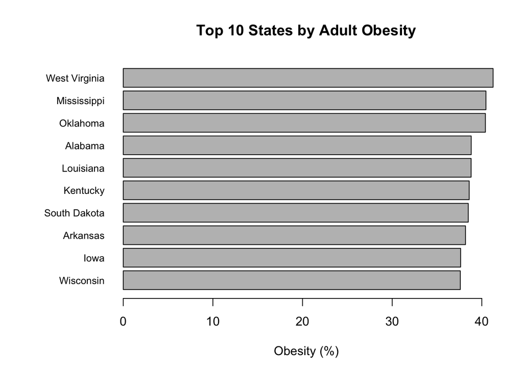

```r
# Top / Bottom 10 obesity states
obesity_state_mean <- tapply(obesity$DataValue, obesity$LocationDesc, mean, na.rm = TRUE)

obesity_state_sorted <- sort(obesity_state_mean)

obesity_top10    <- tail(obesity_state_sorted, 10)
obesity_bottom10 <- head(obesity_state_sorted, 10)

# Top 10
op <- par(mar = c(5, 8, 4, 2))
barplot(obesity_top10,
horiz = TRUE,
las   = 1,
main  = "Top 10 States by Adult Obesity",
xlab  = "Obesity (%)",
cex.names = 0.8)
```

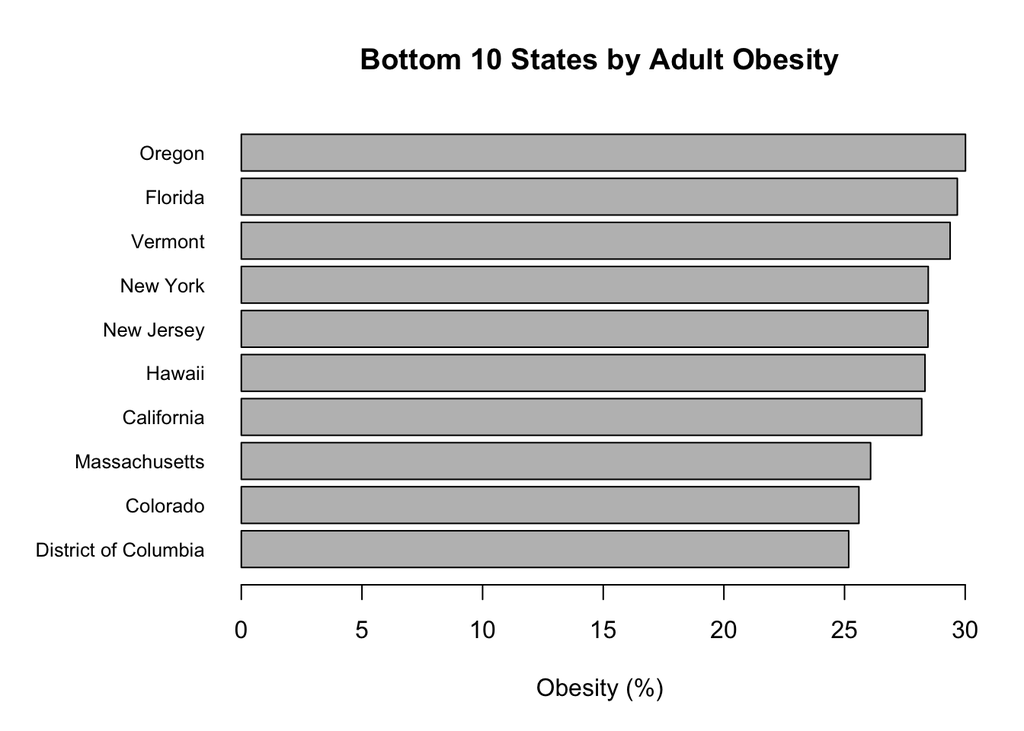

```r
par(op)

# Bottom 10
op <- par(mar = c(5, 8, 4, 2))
barplot(obesity_bottom10,
horiz = TRUE,
las   = 1,
main  = "Bottom 10 States by Adult Obesity",
xlab  = "Obesity (%)",
cex.names = 0.8)
```

```r
par(op)
```

These two barplots highlight which states have the highest and lowest average adult obesity rates. The top-10 chart shows that many of the states with the highest obesity levels are located in the South, while the bottom-10 chart contains several Northeastern and Western states with comparatively lower obesity. This pattern is consistent with common public health concerns about the “stroke belt” and related regional disparities in the South.

### 4.5 Obesity by region

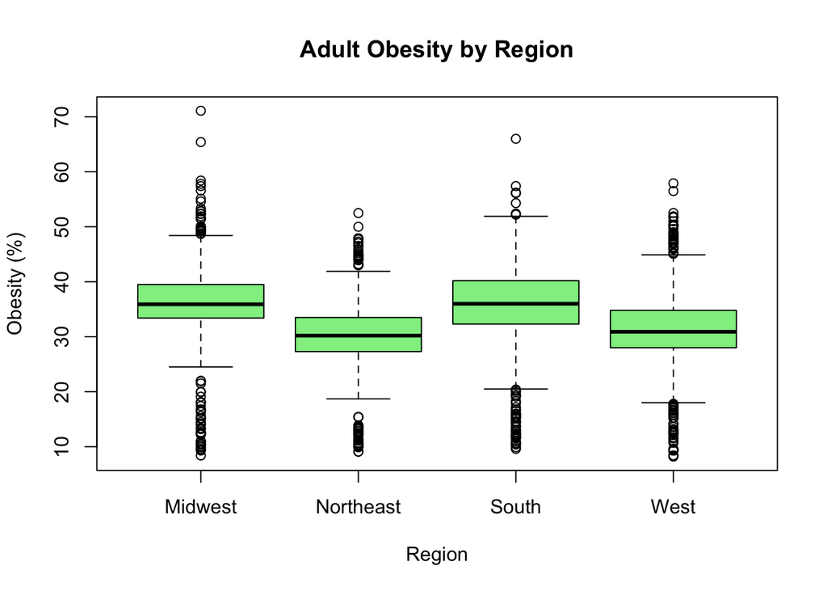

```r
boxplot(DataValue ~ Region, data = obesity,
main = "Adult Obesity by Region",
xlab = "Region",
ylab = "Obesity (%)",
col = "lightgreen")
```

### 4.6 Relationship Between Smoking and Heart Disease

To examine the relationship between adult smoking and heart disease mortality, I aggregate both indicators to the state–year level and merge them.

```r
smoking_state_year <- smoking %>%
group_by(LocationDesc, LocationAbbr, YearStart) %>%
summarise(smoking_rate = mean(DataValue, na.rm = TRUE),
.groups = "drop")

heart_state_year <- heart %>%
group_by(LocationDesc, LocationAbbr, YearStart) %>%
summarise(heart_rate = mean(DataValue, na.rm = TRUE),
.groups = "drop")

smoke_heart <- inner_join(smoking_state_year,
heart_state_year,
by = c("LocationDesc","LocationAbbr","YearStart"))

head(smoke_heart)
```

```
## # A tibble: 6 × 5
##   LocationDesc LocationAbbr YearStart smoking_rate heart_rate
##   <fct>        <chr>            <int>        <dbl>      <dbl>
## 1 Alabama      AL                2019         22.9      1936.
## 2 Alabama      AL                2020         22.6      2123.
## 3 Alabama      AL                2021         18.2      2180.
## 4 Alaska       AK                2019         20.4       204.
## 5 Alaska       AK                2020         19.9       234.
## 6 Alaska       AK                2021         18.9       239.
```

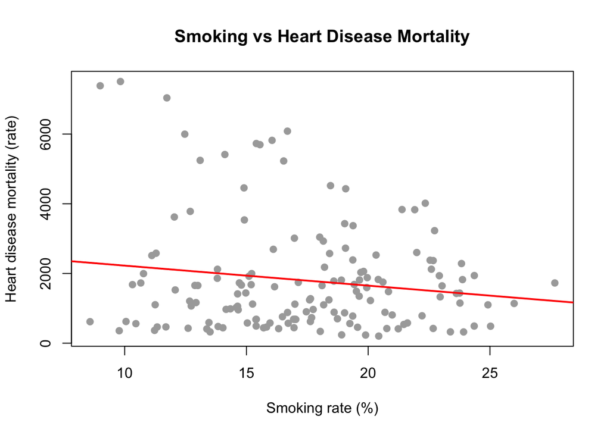

```r
plot(smoke_heart$smoking_rate,
smoke_heart$heart_rate,
main = "Smoking vs Heart Disease Mortality",
xlab = "Smoking rate (%)",
ylab = "Heart disease mortality (rate)",
pch = 19,
col = "darkgray")

abline(lm(heart_rate ~ smoking_rate, data = smoke_heart),
col = "red", lwd = 2)
```

The scatterplot suggests a noisy and weak relationship between smoking prevalence and heart disease mortality at the state–year level. There is no strong linear trend, and the points are widely scattered around the fitted line. The regression results below confirm this impression.

## 5. Statistical Analysis

### 5.1 ANOVA: Obesity differences across regions

I first test whether mean adult obesity rates differ across the four census regions.

```r
obesity_region <- obesity %>%
filter(!is.na(Region))

anova_obesity <- aov(DataValue ~ Region, data = obesity_region)
summary(anova_obesity)
```

```
##               Df Sum Sq Mean Sq F value Pr(>F)
## Region         3  23968    7989   159.8 <2e-16 ***
## Residuals   3746 187284      50
## ---
## Signif. codes:  0 '***' 0.001 '**' 0.01 '*' 0.05 '.' 0.1 ' ' 1
```

```r
TukeyHSD(anova_obesity)
```

```
##   Tukey multiple comparisons of means
##     95% family-wise confidence level
##
## Fit: aov(formula = DataValue ~ Region, data = obesity_region)
##
## $Region
##                         diff           lwr        upr     p adj
## Northeast-Midwest -5.8656126 -6.8090953071 -4.9221299 0.0000000
## South-Midwest     -0.4119612 -1.2069464899  0.3830242 0.5425865
## West-Midwest      -4.9372959 -5.7711643611 -4.1034273 0.0000000
## South-Northeast    5.4536515  4.5599571276  6.3473458 0.0000000
## West-Northeast     0.9283168 -0.0001360175  1.8567696 0.0500499
## West-South        -4.5253347 -5.3024232697 -3.7482461 0.0000000
```

The ANOVA F-test has a very small p-value, so I reject the null hypothesis that mean obesity is equal across regions. The Tukey pairwise comparisons show:

- The South has significantly higher obesity than the Northeast.
- The South is also higher than the West.
- The Midwest is higher than the Northeast, and the West is lower than the South.
- Some pairs (such as South vs Midwest) show smaller or non-significant differences.

Overall, the results support what we saw in the boxplot: regional differences in obesity are not only visible but also statistically significant.

### 5.2 t-test: South vs Other regions

To focus directly on whether the South differs from the rest of the country, I create a binary grouping variable (South vs Other) and run a two-sample t-test.

```r
obesity_region2 <- obesity_region %>%
mutate(South_vs_Other = ifelse(Region == "South", "South", "Other"))

t.test(DataValue ~ South_vs_Other, data = obesity_region2)
```

```
##
##  Welch Two Sample t-test
##
## data:  DataValue by South_vs_Other
## t = -11.573, df = 2420.4, p-value < 2.2e-16
## alternative hypothesis: true difference in means between group Other and group South is not equal to 0
## 95 percent confidence interval:
##  -3.475226 -2.468202
## sample estimates:
## mean in group Other mean in group South
##            32.74130            35.71301
```

The t-test shows a highly significant difference. The South has a higher mean obesity rate (about 35.7%) than the combined average of the other regions (about 32.7%). This result supports the idea that the South faces a disproportionate burden of adult obesity compared to the rest of the country.

### 5.3 Regression: Smoking and heart disease mortality

Next, I fit a simple linear regression model to see whether smoking prevalence alone explains heart disease mortality at the state–year level.

```r
lm1 <- lm(heart_rate ~ smoking_rate, data = smoke_heart)
summary(lm1)
```

```
##
## Call:
## lm(formula = heart_rate ~ smoking_rate, data = smoke_heart)
##
## Residuals:
##     Min      1Q  Median      3Q     Max
## -1883.5 -1086.1  -404.4   484.1  5270.2
##
## Coefficients:
##              Estimate Std. Error t value Pr(>|t|)
## (Intercept)   2802.56     554.29   5.056 1.24e-06 ***
## smoking_rate   -57.52      31.09  -1.850   0.0663 .
## ---
## Signif. codes:  0 '***' 0.001 '**' 0.01 '*' 0.05 '.' 0.1 ' ' 1
##
## Residual standard error: 1556 on 149 degrees of freedom
## Multiple R-squared:  0.02245,    Adjusted R-squared:  0.01589
## F-statistic: 3.423 on 1 and 149 DF,  p-value: 0.06629
```

### 5.4 Multiple regression: Smoking + obesity

Finally, I examine a multiple regression model that includes both smoking and obesity as predictors of heart disease mortality.

```r
obesity_state_year <- obesity %>%
group_by(LocationDesc, LocationAbbr, YearStart) %>%
summarise(obesity_rate = mean(DataValue, na.rm = TRUE),
.groups = "drop")

health_merged <- smoke_heart %>%
left_join(obesity_state_year,
by = c("LocationDesc","LocationAbbr","YearStart"))

lm2 <- lm(heart_rate ~ smoking_rate + obesity_rate,
data = health_merged)
summary(lm2)
```

```
##
## Call:
## lm(formula = heart_rate ~ smoking_rate + obesity_rate, data = health_merged)
##
## Residuals:
##     Min      1Q  Median      3Q     Max
## -1899.2 -1094.4  -435.2   478.0  5285.8
##
## Coefficients:
##              Estimate Std. Error t value Pr(>|t|)
## (Intercept)  2955.051   1042.889   2.834  0.00525 **
## smoking_rate  -52.546     42.447  -1.238  0.21771
## obesity_rate   -7.122     41.206  -0.173  0.86301
## ---
## Signif. codes:  0 '***' 0.001 '**' 0.01 '*' 0.05 '.' 0.1 ' ' 1
##
## Residual standard error: 1561 on 148 degrees of freedom
## Multiple R-squared:  0.02265,    Adjusted R-squared:  0.009444
## F-statistic: 1.715 on 2 and 148 DF,  p-value: 0.1835
```

In this model, neither `smoking_rate` nor `obesity_rate` is statistically significant, and the overall model R-squared remains very low (around 1%). This suggests that, at the level of state–year averages, heart disease mortality is driven by additional factors beyond these two risk indicators, such as age structure, medical care access, and other comorbidities.

## 6. Discussion and Conclusions

Using the U.S. Chronic Disease Indicators dataset, I examined regional differences in adult obesity and explored how smoking and obesity relate to heart disease mortality at the state–year level.

### 6.2 Policy and data implications

From a policy perspective, this analysis suggests that:

1. Efforts to reduce adult obesity in the South could have meaningful impacts on long-term chronic disease burden, especially if combined with broader initiatives around diet, physical activity, and social determinants of health.
2. Surveillance data like the CDI are useful for spotting broad regional patterns and identifying high-risk areas, but they are not enough on their own to fully explain outcomes like mortality. More detailed data—age-adjusted rates, individual-level data, or information stratified by socioeconomic status would be helpful for understanding how behavioral risk factors translate into deaths.
3. Future work could extend this project by adding other CDI indicators (for example, diabetes, hypertension, or access to care) and by trying alternative modeling approaches. For instance, models that focus on age-adjusted rates or that separate states by urban–rural status might capture more of the variation in heart disease mortality.

Overall, these findings answer my original research questions by confirming sizable regional differences in adult obesity, especially in the South, while showing that simple state-level averages of smoking and obesity alone are not sufficient to explain variation in heart disease mortality.